# ST 558 Project 2

Hannah Park 10/15/2020

- Introduction
- Data
- Summarizations
  - Full Data
  - Specific Day of the Week Data: Friday
- Modeling - Day of Week: Friday
  - Tree-based Model
  - Boosted Tree Model
- Model Comparison
  - Table 5. Comparison of root MSE values between models
- Linear Regression Model

# Introduction

Bike sharing systems is a service in which bicycles are made available for shared use to individuals on a short term basis. Bike share systems allow individuals to rent a bike from a particular position and return it at another through an automated process. This automated process, which explicitly records departure and arrival positions and other related observations such as date and duration of the rental, generates a vast amount of data that can be used for research in areas such as traffic, environmental and health issues, mobility in the city, and etc. In this document, data on count of total rental bikes aggregated on daily basis is used to create models for predicting the count using predictors related to the day of the rental and the weather.

The original data set is related to the two-year historical log corresponding to years 2011 and 2012 from Capital Bikeshare system, Washington D.C., USA which is publicly available in [http://capitalbikeshare.com/system-data]. The original data set consists of the following variables:

- instant: record index
- dteday : date
- season : season (1:springer, 2:summer, 3:fall, 4:winter)
- yr : year (0: 2011, 1:2012)
- mnth : month ( 1 to 12)
- holiday : weather day is holiday or not (extracted from [Department of HR Holiday Schedule](http://dchr.dc.gov/page/holiday-schedule))
- weekday : day of the week (0 to 6: Sunday to Monday)
- workingday : if day is neither weekend nor holiday is 1, otherwise is 0.
- weathersit :
  - 1: Clear, Few clouds, Partly cloudy, Partly cloudy
  - 2: Mist + Cloudy, Mist + Broken clouds, Mist + Few clouds, Mist
  - 3: Light Snow, Light Rain + Thunderstorm + Scattered clouds, Light Rain + Scattered clouds
  - 4: Heavy Rain + Ice Pallets + Thunderstorm + Mist, Snow + Fog
- temp : Normalized temperature in Celsius. The values are divided to 41 (max)
- atemp: Normalized feeling temperature in Celsius. The values are divided to 50 (max)
- hum: Normalized humidity. The values are divided to 100 (max)
- windspeed: Normalized wind speed. The values are divided to 67 (max)
- casual: count of casual users
- registered: count of registered users
- cnt: count of total rental bikes including both casual and registered

# Data

```r
# Read in data
url <- "https://archive.ics.uci.edu/ml/machine-learning-databases/00275/Bike-Sharing-Dataset.zip"
download.file(url, "Bike-Sharing-Dataset.zip")
unzip("Bike-Sharing-Dataset.zip", exdir = "./Data")

df.bike <- read_csv("Data/day.csv") %>%
  select(-instant, -casual, -registered) %>%
  mutate(dayofweek = dplyr::recode(weekday,
                            `0` = "Sunday",
                            `1` = "Monday",
                            `2` = "Tuesday",
                            `3` = "Wednesday",
                            `4` = "Thursday",
                            `5` = "Friday",
                            `6` = "Saturday")) %>%
  #Combine variables temp and atemp
  mutate(avgTemp = (temp+atemp)/2)

# Filter by specific day of week
df.bike.day <- df.bike %>%
  filter(dayofweek == params$dayofweek)

#Randomply sample from the data
#Form training and test sets
set.seed(1109)
train <- sample(1:nrow(df.bike.day), size = nrow(df.bike.day)*0.7)
test <- dplyr::setdiff(1:nrow(df.bike.day), train)
df.train <- df.bike.day[train, ]
df.test <- df.bike.day[test, ]
```

# Summarizations

## Full Data

In this section, summary statistics and plots about the original data are provided.

#### Figure 1. Correlation plot

Correlation between all pairs of variables are visualized. High correlations are observed between variables season and month and between temp and atemp.

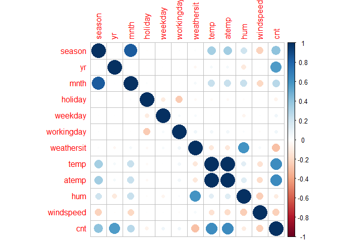

```r
corrplot(cor(df.bike[,2:13]))
```

#### Table 1. Qualitative variables: Contingency tables

Counts of number of holidays and counts of each weather category are provided for each day of week. Factor levels of variable weathersit was re-labeled as Good (1), Moderate (2), Bad (3), and Extreme (4). In years 2011 and 2012, no extreme weather was observed.

```r
df.tbl <- apply_labels(df.bike,
                       dteday = "Date",
                       holiday = "Holiday",
                       holiday = c("No" = 0,
                                   "Yes" = 1),
                       weathersit = "Weather",
                       weathersit = c("Good" = 1,
                                      "Moderate" = 2,
                                      "Bad" = 3,
                                      "Extreme" = 4),
                       weekday = "Day of Week",
                       weekday = c("Sunday" = 0,
                                   "Monday" = 1,
                                   "Tuesday" = 2,
                                   "Wednesday" = 3,
                                   "Thursday" = 4,
                                   "Friday" = 5,
                                   "Saturday" = 6),
                       yr = "Year",
                       mnth = "Month",
                       avgTemp = "Average Temperature",
                       hum = "Humidity",
                       windspeed = "Wind Speed",
                       cnt = "Count of Total Rental Bikes")
attach(df.tbl)
cro_cases(list(holiday, weathersit), df.tbl$weekday,
          total_row_position = "none")
```

|  | Day of Week Sunday | Day of Week Monday | Day of Week Tuesday | Day of Week Wednesday | Day of Week Thursday | Day of Week Friday | Day of Week Saturday |
| --- | --- | --- | --- | --- | --- | --- | --- |
| Holiday |  |  |  |  |  |  |  |
| No | 105 | 90 | 103 | 103 | 102 | 102 | 105 |
| Yes |  | 15 | 1 | 1 | 2 | 2 |  |
| Weather |  |  |  |  |  |  |  |
| Good | 74 | 66 | 62 | 64 | 67 | 63 | 67 |
| Moderate | 30 | 37 | 38 | 33 | 34 | 41 | 34 |
| Bad | 1 | 2 | 4 | 7 | 3 |  | 4 |
| Extreme |  |  |  |  |  |  |  |

```r
detach(df.tbl)
```

#### Figure 2. Histograms of quantitative variables

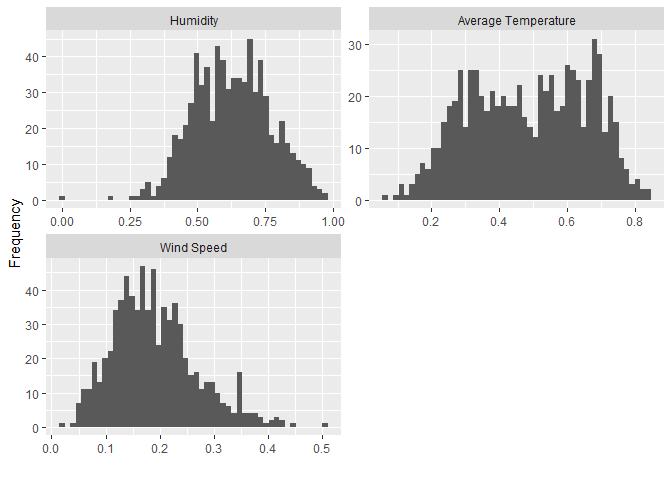

```r
df.bike %>%
  gather(avgTemp, hum, windspeed, key = "var", value = "value") %>%
  mutate(var = factor(var, levels = c("hum", "avgTemp", "windspeed"))) %>%
  ggplot(aes(x = value)) +
  geom_histogram(bins = 50) +
  xlab("") +
  ylab("Frequency") +
  facet_wrap(~var, scales = "free", nrow = 2,
             labeller = as_labeller(c(hum = "Humidity",
                                      avgTemp = "Average Temperature",
                                      windspeed = "Wind Speed")))
```

#### Figure 3. Scatterplot of response variable(cnt) over days

Counts of total rental bikes are plotted against days. Counts were generally higher in year 2012 than 2011, and counts were generally higher in warmer months (June - September) than in colder months. Whether a day was a holiday or not didn’t seem increase or decrease the count when compared to the counts of bike rentals made a few days before and after the holiday.

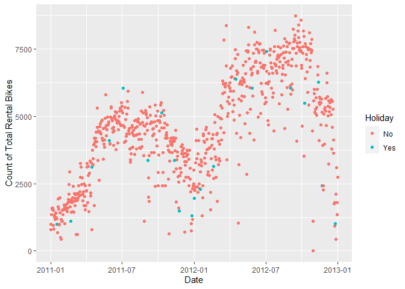

```r
df.bike %>%
  mutate(Holiday = ifelse(holiday == 0, "No", "Yes")) %>%
  ggplot(aes(x = dteday, y = cnt)) +
  geom_point(aes(colour = Holiday)) +
  xlab("Date") +
  ylab("Count of Total Rental Bikes")
```

## Specific Day of the Week Data: Friday

#### Table 2. Qualitative variables: Contingency tables

Counts of variables year, holiday, and weather are displayed for each month.

```r
df.tbl.train <- apply_labels(df.train,
                             dteday = "Date",
                             holiday = "Holiday",
                             holiday = c("No" = 0,
                                         "Yes" = 1),
                             weathersit = "Weather",
                             weathersit = c("Good" = 1,
                                            "Moderate" = 2,
                                            "Bad" = 3,
                                            "Extreme" = 4),
                             dayofweek = "Day of Week",
                             yr = "Year",
                             mnth = "Month",
                             avgTemp = "Average Temperature",
                             hum = "Humidity",
                             windspeed = "Wind Speed",
                             cnt = "Count of Total Rental Bikes")

attach(df.tbl.train)
cro_cases(list(yr, holiday,weathersit), mnth,
          total_row_position = "none")
```

|  | Month 1 | Month 2 | Month 3 | Month 4 | Month 5 | Month 6 | Month 7 | Month 8 | Month 9 | Month 10 | Month 11 | Month 12 |
| --- | --- | --- | --- | --- | --- | --- | --- | --- | --- | --- | --- | --- |
| Year |  |  |  |  |  |  |  |  |  |  |  |  |
| 0 | 3 | 3 | 4 | 5 | 3 | 4 | 4 | 3 | 4 | 1 | 2 | 3 |
| 1 | 3 | 1 | 5 | 2 | 4 | 2 | 2 | 4 | 2 | 2 | 3 | 3 |
| Holiday |  |  |  |  |  |  |  |  |  |  |  |  |
| No | 6 | 4 | 9 | 6 | 7 | 6 | 6 | 7 | 6 | 3 | 5 | 6 |
| Yes |  |  |  | 1 |  |  |  |  |  |  |  |  |
| Weather |  |  |  |  |  |  |  |  |  |  |  |  |
| Good | 3 | 1 | 2 | 4 | 6 | 6 | 5 | 3 | 2 | 3 | 5 | 3 |
| Moderate | 3 | 3 | 7 | 3 | 1 |  | 1 | 4 | 4 |  |  | 3 |
| Bad |  |  |  |  |  |  |  |  |  |  |  |  |
| Extreme |  |  |  |  |  |  |  |  |  |  |  |  |

```r
detach(df.tbl.train)
```

#### Table 3. Quantitative variables: Summary statistics

Minimum, median, mean, and max of the three quantitative variables (average temperature, humidity, and wind speed) are displayed.

```r
df.tbl.train %>%
  tab_cells(avgTemp, hum, windspeed) %>%
  tab_cols(mnth) %>%
  tab_stat_fun(Minimum = w_min, Median = w_median,
               Mean = w_mean, Max = w_max) %>%
  tab_pivot()
```

|  | Month 1 | Month 2 | Month 3 | Month 4 | Month 5 | Month 6 | Month 7 | Month 8 | Month 9 | Month 10 | Month 11 | Month 12 |
| --- | --- | --- | --- | --- | --- | --- | --- | --- | --- | --- | --- | --- |
| Average Temperature |  |  |  |  |  |  |  |  |  |  |  |  |
| Minimum | 0.2 | 0.2 | 0.3 | 0.3 | 0.5 | 0.6 | 0.6 | 0.7 | 0.6 | 0.4 | 0.3 | 0.3 |
| Median | 0.2 | 0.4 | 0.4 | 0.4 | 0.5 | 0.7 | 0.7 | 0.7 | 0.6 | 0.5 | 0.4 | 0.3 |
| Mean | 0.2 | 0.4 | 0.4 | 0.4 | 0.6 | 0.7 | 0.7 | 0.7 | 0.6 | 0.5 | 0.3 | 0.3 |
| Max | 0.3 | 0.5 | 0.6 | 0.5 | 0.7 | 0.8 | 0.8 | 0.7 | 0.6 | 0.6 | 0.4 | 0.4 |
| Humidity |  |  |  |  |  |  |  |  |  |  |  |  |
| Minimum | 0.4 | 0.5 | 0.4 | 0.4 | 0.4 | 0.4 | 0.4 | 0.6 | 0.6 | 0.5 | 0.4 | 0.5 |
| Median | 0.5 | 0.6 | 0.6 | 0.7 | 0.7 | 0.6 | 0.6 | 0.6 | 0.7 | 0.6 | 0.5 | 0.6 |
| Mean | 0.5 | 0.6 | 0.6 | 0.6 | 0.6 | 0.6 | 0.6 | 0.7 | 0.8 | 0.6 | 0.5 | 0.6 |
| Max | 0.8 | 0.7 | 0.8 | 0.8 | 0.9 | 0.7 | 0.8 | 0.8 | 1.0 | 0.7 | 0.6 | 0.8 |
| Wind Speed |  |  |  |  |  |  |  |  |  |  |  |  |
| Minimum | 0.1 | 0.1 | 0.1 | 0.1 | 0.1 | 0.1 | 0.1 | 0.1 | 0.1 | 0.0 | 0.1 | 0.1 |
| Median | 0.2 | 0.3 | 0.2 | 0.2 | 0.2 | 0.2 | 0.2 | 0.2 | 0.1 | 0.1 | 0.2 | 0.2 |
| Mean | 0.2 | 0.2 | 0.2 | 0.2 | 0.2 | 0.2 | 0.2 | 0.2 | 0.1 | 0.1 | 0.2 | 0.2 |
| Max | 0.4 | 0.3 | 0.4 | 0.3 | 0.2 | 0.3 | 0.2 | 0.2 | 0.2 | 0.2 | 0.3 | 0.4 |

#### Figure 4. Qualitative variables: Boxplots

Boxplots of qualitative variables (year, month, holiday and weather) are displayed.

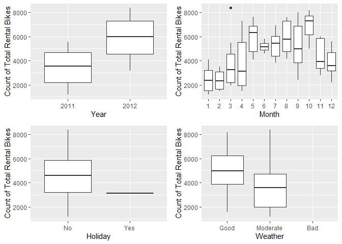

```r
boxplot1 <- df.train %>%
  ggplot(aes(x = factor(mnth), y = cnt)) +
  geom_boxplot() +
  xlab("Month") +
  ylab("Count of Total Rental Bikes")

boxplot2 <- df.train %>%
  ggplot(aes(x = factor(weathersit), y = cnt)) +
  geom_boxplot() +
  xlab("Weather") +
  ylab("Count of Total Rental Bikes") +
  scale_x_discrete(limits = c("1", "2", "3"),
                   labels = c("1" = "Good", "2" = "Moderate", "3" = "Bad"))

boxplot3 <- df.train %>%
  ggplot(aes(x = factor(holiday), y = cnt)) +
  geom_boxplot() +
  xlab("Holiday") +
  ylab("Count of Total Rental Bikes") +
  scale_x_discrete(limits = c("0", "1"),
                   labels = c("0" = "No", "1" = "Yes"))

boxplot4 <- df.train %>%
  ggplot(aes(x = factor(yr), y = cnt)) +
  geom_boxplot() +
  xlab("Year") +
  ylab("Count of Total Rental Bikes") +
  scale_x_discrete(limits = c("0", "1"),
                   labels = c("0" = "2011", "1" = "2012"))

grid.arrange(boxplot4, boxplot1, boxplot3, boxplot2)
```

#### Figure 5. Quantitative variables: Scatterplots

Scatterplot of quantitative variables (Humidity, Average Temperature, and Wind Speed) are displayed.

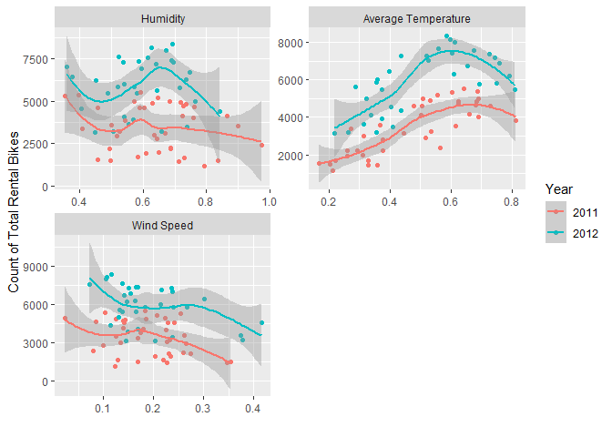

```r
df.train %>%
  gather(avgTemp, hum, windspeed, key = "var", value = "value") %>%
  mutate(var = factor(var, levels = c("hum", "avgTemp", "windspeed")),
         Year = ifelse(yr == 0, "2011", "2012")) %>%
  ggplot(aes(x = value, y = cnt, color = Year)) +
  geom_point() +
  geom_smooth(aes(group = Year)) +
  xlab("") +
  ylab("Count of Total Rental Bikes") +
  facet_wrap(~var, scales = "free", nrow = 2,
             labeller = as_labeller(c(hum = "Humidity",
                                      avgTemp = "Average Temperature",
                                      windspeed = "Wind Speed")))
```

# Modeling - Day of Week: Friday

Two models are fitted: a tree-based model chosen using leave one out cross validation (LOOCV) that is non-ensemble and a boosted tree model chosen using cross-validation (CV). For both models, the response variable is the **Count of Total Rental Bikes** (cnt), and the predictor variables are year (yr), month (mnth), holiday, weather (weathersit), average temperature (average of temp and atemp), humidity (hum), and wind speed (windspeed).

## Tree-based Model

A regression tree is fitted using recursive binary splitting to predict the continous response cnt. For every possible value of each predictor, the optimal value that minimizes the Residual Sum of Squares (RSS) is found, and the predictor and its optimal value with the smallest RSS is chosen to split the predictor space into two. This process is repeated to further split the predictor space into several regions (nodes of the tree). To avoid overfitting the data, LOOCV is used to prune back the tree and choose the right number of nodes that decreases variance but improves prediction.

### Model fit

```r
fit.tree <- train(cnt ~ yr + mnth + holiday + weathersit + avgTemp + hum + windspeed,
                  data = df.train,
                  method = "rpart",
                  trControl = trainControl(method = "LOOCV"))
```

### Full result

The results of the regression tree model and plot of the decision tree are displayed below.

```r
kable(fit.tree$results)
```

| cp | RMSE | Rsquared | MAE |
| --- | --- | --- | --- |
| 0.1707028 | 1380.521 | 0.4826741 | 1142.158 |
| 0.1877637 | 1584.389 | 0.3152068 | 1422.373 |
| 0.4129479 | 2163.815 | 0.0296047 | 2002.345 |

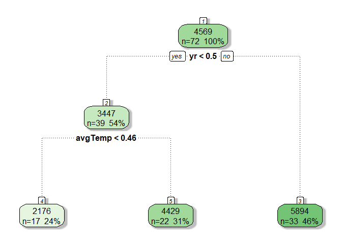

```r
fancyRpartPlot(fit.tree$finalModel,
               sub = "")
```

### Final chosen model

Model with the smallest Cp value is chosen as the final regression tree model, and for our training data, the final model has a Cp value of 0.1707028.

### Predictions on the test set

```r
pred.tree <- predict(fit.tree, newdata = df.test)
RMSE.tree <- sqrt(mean((pred.tree-df.test$cnt)^2))
```

## Boosted Tree Model

In a boosted tree model, tree are added subsequentially, resulting in slow training of trees that helps prevent overfitting of the data. Boosted tree model sequentially combines trees: each new tree fits to the residuals from the previous step. There are three tuning parameters associated with boosting: (\lambda) - a shrinkage parameter that slows the fitting process, *B* - number of boosting iterations, and *d* - maximum tree depth. Cross validation (CV) is used in our model to select the tuning parameters.

### Model fit

```r
fit.boost <- train(cnt ~ yr + mnth + holiday + weathersit + avgTemp + hum + windspeed,
                   data = df.train,
                   method = "gbm",
                   trControl = trainControl(method = "cv", number = 10),
                   verbose = FALSE)
```

### Full result

The result of the boosted tree model, displaying the different combinations of tuning parameters and their respective RMSE, and plot of the result are provided below.

```r
kable(fit.boost$results[c(1,4,2,5)],
      col.names = c("Shrinkage",
                    "Boosting Iterations",
                    "Max Tree Depth",
                    "RMSE"),
      row.names = FALSE)
```

| Shrinkage | Boosting Iterations | Max Tree Depth | RMSE |
| --- | --- | --- | --- |
| 0.1 | 50 | 1 | 885.5900 |
| 0.1 | 50 | 2 | 882.9917 |
| 0.1 | 50 | 3 | 867.8374 |
| 0.1 | 100 | 1 | 851.6767 |
| 0.1 | 100 | 2 | 897.2474 |
| 0.1 | 100 | 3 | 852.0119 |
| 0.1 | 150 | 1 | 848.2693 |
| 0.1 | 150 | 2 | 899.1495 |
| 0.1 | 150 | 3 | 870.7514 |

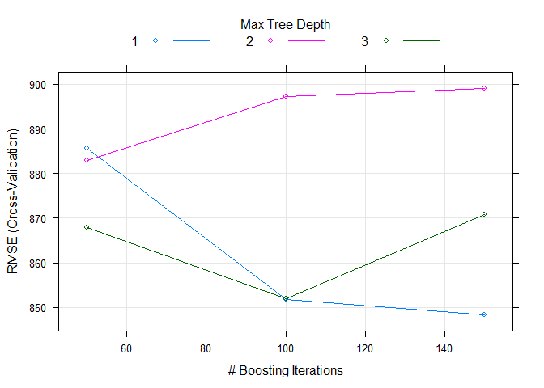

```r
plot(fit.boost)
```

### Final chosen model

Model with the smallest RMSE value is chosen as the final boosted tree model. For our training data, model with the tuning parameters provided in Table 4 is chosen via cross validation method.

#### Table 4. Values of tuning parameters from the final boosted tree model

```r
kable(fit.boost$bestTune[c(3,1,2)],
      col.names = c("Shrinkage",
                    "Boosting Iterations",
                    "Max Tree Depth"),
      row.names = FALSE)
```

| Shrinkage | Boosting Iterations | Max Tree Depth |
| --- | --- | --- |
| 0.1 | 150 | 1 |

### Predictions on the test set

```r
pred.boost <- predict(fit.boost, newdata = df.test)
RMSE.boost <- sqrt(mean((pred.boost-df.test$cnt)^2))
```

# Model Comparison

The two final models chosen based on LOOCV (regression tree) and CV (boosted tree) can be compared with their respective RMSE value. The boosted tree model is expected to perform better, and thus have a smaller RMSE value, since boosted tree models are generally better at prediction than non-ensemble, single tree models (regression tree).

#### Table 5. Comparison of root MSE values between models

```r
kable(c("Regression Tree" = RMSE.tree, "Boosted Tree" = RMSE.boost),
      col.names = "RMSE")
```

|  | RMSE |
| --- | --- |
| Regression Tree | 1465.2702 |
| Boosted Tree | 843.6968 |

# Linear Regression Model

This is part 2 of the project, performed by Jackie Steffan.

Here I am creating a linear regression model. I used the variables Hannah used for her tree model to see if this would be a better predictor than the trees (which it most likely will not be).

```r
linMod <- lm(cnt ~ yr + mnth + holiday + weathersit + avgTemp + hum + windspeed, data= df.train)
preds <- cbind(df.test$cnt, predict(linMod, newdata= df.test))
colnames(preds) <- c("Test Set", "Predictions")
preds
```

```
##    Test Set Predictions
## 1      1421    2132.083
## 2      1746    2462.826
## 3      4679    4245.514
## 4      3387    5848.768
## 5      4905    5424.047
## 6      4760    3543.212
## 7      3644    3554.667
## 8      4304    3661.969
## 9      3747    2683.743
## 10     4046    2934.354
## 11     3368    3084.966
## 12     3940    3646.843
## 13     3620    3495.596
## 14     3456    3954.557
```

[output cut: 18 more lines]